# COVID Outcomes Data Comparison

Graham Tyler

4/21/2020

```r
### knitr setup
knitr::opts_chunk$set(
  warning = F,
  message = F
)

### R setup

library(tidyverse)
library(zoo)
library(sf)

### Import data

# Download time series data from Corona Data Scraper.
cds <- read_csv("/Users/grahamtyler/Downloads/timeseries-tidy 6.csv")

# Note: We can pull updated version of this dataset directly through URL below, but it does not get parsed correctly and we lose the county and state names.
# cds <- read_csv(url("https://coronadatascraper.com/timeseries-tidy.csv"))

# Download current US counties dataset from NYT github.
nyt <- read_csv(url("https://raw.githubusercontent.com/nytimes/covid-19-data/master/us-counties.csv"))

# Download current US confirmed cases and US deaths datasets from Jonhs Hopkins github.
jh_confirmed_us <- read_csv(url("https://raw.githubusercontent.com/CSSEGISandData/COVID-19/master/csse_covid_19_data/csse_covid_19_time_series/time_series_covid19_confirmed_US.csv"))

jh_deaths_us <- read_csv(url("https://raw.githubusercontent.com/CSSEGISandData/COVID-19/master/csse_covid_19_data/csse_covid_19_time_series/time_series_covid19_deaths_US.csv"))
```

## CDS data exploration and cleanup

```r
head(cds)
```

```
## # A tibble: 6 x 14
##   name  level city  county state country population   lat  long aggregate tz
##   <chr> <chr> <lgl> <chr>  <chr> <chr>        <dbl> <dbl> <dbl> <lgl>     <chr>
## 1 Antw… coun… NA    Antwe… Flan… Belgium    1847486  51.2  4.72 NA        Euro…
## 2 Antw… coun… NA    Antwe… Flan… Belgium    1847486  51.2  4.72 NA        Euro…
## 3 Antw… coun… NA    Antwe… Flan… Belgium    1847486  51.2  4.72 NA        Euro…
## 4 Antw… coun… NA    Antwe… Flan… Belgium    1847486  51.2  4.72 NA        Euro…
## 5 Antw… coun… NA    Antwe… Flan… Belgium    1847486  51.2  4.72 NA        Euro…
## 6 Antw… coun… NA    Antwe… Flan… Belgium    1847486  51.2  4.72 NA        Euro…
## # … with 3 more variables: date <date>, type <chr>, value <dbl>
```

```r
# Widen dataframe to create separate columns for cases, deaths, tests, etc.
cds <- cds %>%
  pivot_wider(names_from = type, values_from = value)

# Filter to US only at the county level.
cds <- cds %>%
  filter(country == "United States" & level == "county")

# Check for missing data.
print(cds %>% summarise_all(funs(sum(is.na(.)))), width = Inf)
```

```
## # A tibble: 1 x 20
##    name level   city county state country population   lat  long aggregate    tz
##   <int> <int>  <int>  <int> <int>   <int>      <int> <int> <int>     <int> <int>
## 1     0     0 279927      0     0       0         81    81    81    279927    81
##    date cases hospitalized discharged deaths tested growthFactor recovered
##   <int> <int>        <int>      <int>  <int>  <int>        <int>     <int>
## 1     0    44       279927     279927  45872 263093       279927    268821
##   active
##    <int>
## 1 268862
```

Data is mostly limited to cases and deaths, with some testing, recovered, active data. One problem with CDS is that they don’t provide the FIPS codes for there time series dataset, so initial join to other datasets will be on state, county, date.

```r
# Check which places are missing location and population data.

cds %>%
  group_by(name) %>%
  filter(is.na(population) | is.na(lat) | is.na(long) | is.na(tz)) %>%
  summarise(count = n())
```

```
## # A tibble: 8 x 2
##   name                                                         count
##   <chr>                                                        <int>
## 1 Anchorage Economic Region, AK, USA                               9
## 2 Dukes County, Nantucket County, Massachusetts, United States    18
## 3 Gulf Coast Economic Region, AK, USA                              9
## 4 Interior Economic Region, AK, USA                                9
## 5 Mat-Su Economic Region, AK, USA                                  9
## 6 Northern Economic Region, AK, USA                                9
## 7 Southeast Economic Region, AK, USA                               9
## 8 Southwest Economic Region, AK, USA                               9
```

```r
# Check the data for Dukes and Nantucket.

cds %>%
  filter(grepl("Dukes", county)) %>%
  group_by(name, county) %>%
  summarise(count = n(), min(date), max(date), sum(cases, na.rm = TRUE), sum(deaths, na.rm = TRUE), max(cases, na.rm = TRUE), max(deaths, na.rm = TRUE))
```

```
## # A tibble: 2 x 9
## # Groups:   name [2]
##   name  county count `min(date)` `max(date)` `sum(cases, na.… `sum(deaths, na…
##   <chr> <chr>  <int> <date>      <date>                 <dbl>            <dbl>
## 1 Duke… Dukes…    89 2020-01-22  2020-04-19               192               11
## 2 Duke… Dukes…    18 2020-03-21  2020-04-07               151                2
## # … with 2 more variables: `max(cases, na.rm = TRUE)` <dbl>, `max(deaths, na.rm
## #   = TRUE)` <dbl>
```

```r
cds <- cds %>%
  filter(name != "Dukes County, Nantucket County, Massachusetts, United States")

# Also drop the Economic Region data.
cds <- cds %>%
  filter(!grepl("Economic Region", name))

# Check the missing case data.
cds %>% group_by(name) %>%
  filter(is.na(cases)) %>%
  summarise(count = n())
```

```
## # A tibble: 1 x 2
##   name                                                  count
##   <chr>                                                 <int>
## 1 District of Columbia, Washington, D.C., United States    44
```

All of the missing case data appears to be early on in DC.

```r
# Drop these rows with no case data.
cds <- cds %>% drop_na(cases)
```

Missing deaths data should, in theory, only be for each county after it registers a case, but before it records a death.

```r
# Pull counties with missing deaths data AFTER registering first death.

cds_death_na_dates <- cds %>%
  group_by(name, state, county) %>%
  summarise(last_na = max(date[which(is.na(deaths))])
            , first_death = min(date[which(deaths > 0)])) %>%
  filter(last_na > first_death)

nrow(cds_death_na_dates)
```

```
## [1] 155
```

There are a fair number of these cases, similar to the other datasets. Would need to impute these values.

```r
# Check which entries have the most cases for a given day with NA or 0 deaths.
cds_death_case_check <- cds %>%
  filter(is.na(deaths) | deaths == 0) %>%
  arrange(desc(cases))

head(cds_death_case_check)
```

```
## # A tibble: 6 x 20
##   name  level city  county state country population   lat  long aggregate tz
##   <chr> <chr> <lgl> <chr>  <chr> <chr>        <dbl> <dbl> <dbl> <lgl>     <chr>
## 1 Quee… coun… NA    Queen… New … United…    2253858  40.7 -73.8 NA        Amer…
## 2 Quee… coun… NA    Queen… New … United…    2253858  40.7 -73.8 NA        Amer…
## 3 Quee… coun… NA    Queen… New … United…    2253858  40.7 -73.8 NA        Amer…
## 4 Quee… coun… NA    Queen… New … United…    2253858  40.7 -73.8 NA        Amer…
## 5 Quee… coun… NA    Queen… New … United…    2253858  40.7 -73.8 NA        Amer…
## 6 Quee… coun… NA    Queen… New … United…    2253858  40.7 -73.8 NA        Amer…
## # … with 9 more variables: date <date>, cases <dbl>, hospitalized <dbl>,
## #   discharged <dbl>, deaths <dbl>, tested <dbl>, growthFactor <dbl>,
## #   recovered <dbl>, active <dbl>
```

Deaths data for counties around and including NYC is missing or 0, but cases are included for these counties. Also missing deaths for major NJ counties.

Therefore, this is NOT a good source for deaths.

```r
# Run the same NA checks for the testing data

cds_test_na_dates <- cds %>% group_by(name, state, county) %>%
  summarise(last_na = max(date[which(is.na(tested))])
            , first_test = min(date[which(tested > 0)])
            , na_count = sum(is.na(tested))) %>%
  filter(last_na > first_test)

nrow(cds_test_na_dates)
```

```
## [1] 461
```

```r
#Again, there are a fair amount of counties with NA tests in the middle of the testing data.
#We will linearly interpolate tests for missing values by county later on.



#This doesn't really seem to be an issue.
```

There are a fair amount of counties with missing testing data in the middle of the dataset after registering the first test. Revisit this after joining the datasets.

```r
# Check if there are gaps in the dates for any counties. It should be that once cases/testing start, we have continuous entries each day.
cds %>%
  arrange(name, state, county, date) %>%
  mutate(date_gap = date - lag(date)) %>%
  filter(date_gap > 1)
```

```
## # A tibble: 6 x 21
##   name  level city  county state country population   lat  long aggregate tz
##   <chr> <chr> <lgl> <chr>  <chr> <chr>        <dbl> <dbl> <dbl> <lgl>     <chr>
## 1 Beav… coun… NA    Beave… Utah  United…     252042  37.8 -112. NA        Amer…
## 2 Box … coun… NA    Box E… Utah  United…     186818  41.5 -113. NA        Amer…
## 3 Carb… coun… NA    Carbo… Utah  United…      40229  39.2 -110. NA        Amer…
## 4 Juab… coun… NA    Juab … Utah  United…      81954  39.1 -112. NA        Amer…
## 5 Uint… coun… NA    Uinta… Utah  United…      56622  40.2 -110. NA        Amer…
## 6 Webe… coun… NA    Weber… Utah  United…     272337  41.1 -112. NA        Amer…
## # … with 10 more variables: date <date>, cases <dbl>, hospitalized <dbl>,
## #   discharged <dbl>, deaths <dbl>, tested <dbl>, growthFactor <dbl>,
## #   recovered <dbl>, active <dbl>, date_gap <drtn>
```

This does not seem to be an issue.

## CDS Overview

We will only use the CDS testing data, not the cases or deaths data.

The website indicates that these states have testing data by county from DOH in this dataset: AK, ND, NY, OR, TN, WI, and DC. CA also has testing by county in the CDS dataset, but it is piecemeal from various sources saved in a spreadsheet. Ben Welsh at the LA Times indicated that DOH is not giving out testing by county in CA.

# End data checks and cleanup for CDS data.

## Johns Hopkins data exploration and cleanup

```r
# Generate character vector of dates corresponding to JH column names.
dates <- str_remove(str_replace_all(as.character(format(seq.Date(as.Date("2020/1/22"), as.Date(Sys.Date()-1), by = "day"), "%m/%d/%y")), "/0", "/"), "^0+")

# Lengthen JH datasets to have a row for each date for each county.

jh_confirmed_us <- jh_confirmed_us %>%
  pivot_longer(cols = all_of(dates), names_to = "date", values_to = "cases")

jh_deaths_us <- jh_deaths_us %>%
  pivot_longer(cols = all_of(dates), names_to = "date", values_to = "deaths")

# Combine the two JH datasets.

jh <-jh_confirmed_us %>% left_join(select(jh_deaths_us, UID, date, Population, deaths), by = c("UID", "date"))

# Check to make sure nothing is lost in the join.
anti_join(jh_confirmed_us, jh_deaths_us, by = c("UID", "date"))
```

```
## # A tibble: 0 x 13
## # … with 13 variables: UID <dbl>, iso2 <chr>, iso3 <chr>, code3 <dbl>,
## #   FIPS <dbl>, Admin2 <chr>, Province_State <chr>, Country_Region <chr>,
## #   Lat <dbl>, Long_ <dbl>, Combined_Key <chr>, date <chr>, cases <dbl>
```

Join seems to be fine.

```r
head(jh)
```

```
## # A tibble: 6 x 15
##     UID iso2  iso3  code3  FIPS Admin2 Province_State Country_Region   Lat Long_
##   <dbl> <chr> <chr> <dbl> <dbl> <chr>  <chr>          <chr>          <dbl> <dbl>
## 1    16 AS    ASM      16    60 <NA>   American Samoa US             -14.3 -170.
## 2    16 AS    ASM      16    60 <NA>   American Samoa US             -14.3 -170.
## 3    16 AS    ASM      16    60 <NA>   American Samoa US             -14.3 -170.
## 4    16 AS    ASM      16    60 <NA>   American Samoa US             -14.3 -170.
## 5    16 AS    ASM      16    60 <NA>   American Samoa US             -14.3 -170.
## 6    16 AS    ASM      16    60 <NA>   American Samoa US             -14.3 -170.
## # … with 5 more variables: Combined_Key <chr>, date <chr>, cases <dbl>,
## #   Population <dbl>, deaths <dbl>
```

```r
# Check missing values.
print(jh %>% summarise_all(funs(sum(is.na(.)))), width = Inf)
```

```
## # A tibble: 1 x 15
##     UID  iso2  iso3 code3  FIPS Admin2 Province_State Country_Region   Lat Long_
##   <int> <int> <int> <int> <int>  <int>          <int>          <int> <int> <int>
## 1     0     0     0     0   900    630              0              0     0     0
##   Combined_Key  date cases Population deaths
##          <int> <int> <int>      <int>  <int>
## 1            0     0     0          0      0
```

```r
# Check missing FIPS by county.
print(jh %>% filter(is.na(FIPS)) %>%
  group_by(Province_State, Admin2) %>%
  summarise(count = n()), n = Inf)
```

```
## # A tibble: 10 x 3
## # Groups:   Province_State [4]
##    Province_State Admin2                                    count
##    <chr>          <chr>                                     <int>
##  1 Massachusetts  Dukes and Nantucket                          90
##  2 Michigan       Federal Correctional Institution (FCI)       90
##  3 Michigan       Michigan Department of Corrections (MDOC)    90
##  4 Missouri       Kansas City                                  90
##  5 Utah           Bear River                                   90
##  6 Utah           Central Utah                                 90
##  7 Utah           Southeast Utah                               90
##  8 Utah           Southwest Utah                               90
##  9 Utah           TriCounty                                    90
## 10 Utah           Weber-Morgan                                 90
```

Kansas City is part of four different counties. My understanding is that Kansas City, Missouri outcomes are being counted separately and the data for those counties is omitting KC data. This is fine for now, but we may need a workaround for mapping by county. This seems to be consistent in all of the datasets.

```r
# Check missing county name by FIPS.
print(jh %>% filter(is.na(Admin2)) %>%
        group_by(Province_State, FIPS) %>%
        summarise(count = n()), n = Inf)
```

```
## # A tibble: 7 x 3
## # Groups:   Province_State [7]
##   Province_State            FIPS count
##   <chr>                    <dbl> <int>
## 1 American Samoa              60    90
## 2 Diamond Princess         88888    90
## 3 Grand Princess           99999    90
## 4 Guam                        66    90
## 5 Northern Mariana Islands    69    90
## 6 Puerto Rico                 72    90
## 7 Virgin Islands              78    90
```

Missing county name only seems to be an issue for territories and the data coded as being on a cruise ship, all of which we will ignore for now.

```r
# Hard code a FIPS of 29000 for KC (which I've confirmed does not belong to any other county) and hard code Dukes and Nantucket FIPS.
jh <- jh %>%
  mutate(FIPS = ifelse(is.na(FIPS) & Admin2=="Dukes and Nantucket", 25007, FIPS)) %>%
  mutate(FIPS = ifelse(is.na(FIPS) & Admin2=="Kansas City" & Province_State=="Missouri", 29000, FIPS))

# Because we will use Dukes and Nantucket county, but Dukes County has the population data in the JH dataset, we will add that population count for Dukes and Nantucket.

jh <- jh %>% left_join(select(jh, FIPS, Admin2, date, Population) %>%
                               filter(FIPS == 25007 & Admin2 == "Dukes"), by = c("FIPS", "date"), suffix = c("", ".Dukes")) %>%
  mutate(Population = ifelse(FIPS == 25007 & Admin2 == "Dukes and Nantucket", Population.Dukes, Population)) %>%
  select (-c(Admin2.Dukes, Population.Dukes))
```

Note that we may need to pull population data from another source, as the JH population county for NYC seems off and I’m not sure where they are getting the population data from.

JH data has an “Unassigned” county for each state to capture cases and deaths not assigned to a county on the date the data was recorded. These seem to fluctuate as cases get assigned to counties later on. There is also an “Out of X”, which I believe is assigned to people from another state who were treated in the given state.

The NYT data counts patients where they are treated, not necessarily where they are from.

```r
# Sum total cases, deaths and get max (which should be for yesterday's total) for Unassigned counties and the "Out of State" designation.

jh_unknown <- jh %>%
  filter(Admin2 == "Unassigned" | grepl("Out of", Admin2)) %>%
  group_by(FIPS, Province_State, Admin2) %>%
  summarise(sum_cases = sum(cases), sum_deaths = sum(deaths), max_cases = max(cases), max_deaths = max(deaths))
```

```r
# Now remove all NA rows to trim dataset to established counties with FIPS + KC.
jh <- jh %>% drop_na()

#Drop Dukes County, which has no data. Will just use "Dukes and Nantucket" with the correct FIPS code.
# Drop Unassigned  and "Out of" counties.

jh <- jh %>%
  filter(!(FIPS == 25007 & Admin2 == "Dukes")) %>%
  filter(Admin2 != "Unassigned") %>%
  filter(!grepl("Out of", Admin2))
```

From previous look, I also found out that NYT uses the full FIPS code including a leading zero for some counties, which matches the census FIPS code, while JH drops the leading zero. Counties only have at most 1 leading zero.

```r
# Add leading zero to all JH FIPS codes with only 4 digits and adjust date format to match NYT.
jh <- jh %>% mutate(FIPS = as.character(ifelse(nchar(FIPS) == 4, paste0("0", FIPS), FIPS))
                    , date = as.Date(date, format = "%m/%d/%y"))

# Trim down the JH dataset to only the relevant columns and rename them.
jh <- jh %>% select(UID, FIPS, full_name = Combined_Key, country = Country_Region, state = Province_State, county = Admin2, date
                    , cases, deaths, population.jh = Population, lat = Lat, long = Long_)
```

# End data checks and cleanup for JH data.

## NYT data exploration and cleanup

```r
head(nyt)
```

```
## # A tibble: 6 x 6
##   date       county    state      fips  cases deaths
##   <date>     <chr>     <chr>      <chr> <dbl>  <dbl>
## 1 2020-01-21 Snohomish Washington 53061     1      0
## 2 2020-01-22 Snohomish Washington 53061     1      0
## 3 2020-01-23 Snohomish Washington 53061     1      0
## 4 2020-01-24 Cook      Illinois   17031     1      0
## 5 2020-01-24 Snohomish Washington 53061     1      0
## 6 2020-01-25 Orange    California 06059     1      0
```

```r
# Check missing values.

print(nyt %>% summarise_all(funs(sum(is.na(.)))), width = Inf)
```

```
## # A tibble: 1 x 6
##    date county state  fips cases deaths
##   <int>  <int> <int> <int> <int>  <int>
## 1     0      0     0   961     0      0
```

```r
# The only NA's are for fips. Check which counties these are associated with.
print(nyt %>% filter(is.na(fips)) %>%
  group_by(state, county) %>%
  summarise(count = n()), n= Inf) %>%
  arrange(county)
```

```
## # A tibble: 46 x 3
## # Groups:   state [44]
##    state                    county        count
##    <chr>                    <chr>         <int>
##  1 Alaska                   Unknown           2
##  2 Arizona                  Unknown          10
##  3 Arkansas                 Unknown          32
##  4 California               Unknown          12
##  5 Colorado                 Unknown          30
##  6 Connecticut              Unknown          22
##  7 Delaware                 Unknown          10
##  8 Florida                  Unknown          29
##  9 Georgia                  Unknown          32
## 10 Guam                     Unknown          37
## 11 Hawaii                   Unknown          25
```

[output cut: 35 more lines]

```
## # A tibble: 46 x 3
## # Groups:   state [44]
##    state       county        count
##    <chr>       <chr>         <int>
##  1 Missouri    Kansas City      32
##  2 New York    New York City    51
##  3 Alaska      Unknown           2
##  4 Arizona     Unknown          10
##  5 Arkansas    Unknown          32
##  6 California  Unknown          12
##  7 Colorado    Unknown          30
##  8 Connecticut Unknown          22
##  9 Delaware    Unknown          10
## 10 Florida     Unknown          29
## # … with 36 more rows
```

There are a bunch of “Unknown” county names, plus KC and NYC.

```r
# Hard code KC FIPS that we used for JH dataset and hard code NYC value.
nyt <- nyt %>%
  mutate(fips = ifelse(is.na(fips) & county=="New York City" & state=="New York", "36061", fips)) %>%
  mutate(fips = ifelse(is.na(fips) & county=="Kansas City" & state=="Missouri", "29000", fips))
```

```r
# Check to see if there are gaps in the dates for any counties. It should be that once cases start, we have continuous entries each day.
print(nyt %>%
  arrange(fips, state, county, date) %>%
  mutate(date_gap = date - lag(date)) %>%
  filter(date_gap > 1)
  , n=Inf)
```

```
## # A tibble: 78 x 7
##    date       county       state          fips  cases deaths date_gap
##    <date>     <chr>        <chr>          <chr> <dbl>  <dbl> <drtn>
##  1 2020-04-12 Geneva       Alabama        01061     1      0  4 days
##  2 2020-04-09 Perry        Alabama        01105     2      0  3 days
##  3 2020-03-29 Hempstead    Arkansas       05057     1      0  2 days
##  4 2020-03-31 Habersham    Georgia        13137     2      0  2 days
##  5 2020-04-06 Jeff Davis   Georgia        13161     1      0  5 days
##  6 2020-04-02 Telfair      Georgia        13271     2      0  7 days
##  7 2020-03-28 Walton       Georgia        13297     2      0  2 days
##  8 2020-04-02 Logan        Illinois       17107     1      0  8 days
##  9 2020-04-04 Mason        Illinois       17125     1      0  3 days
## 10 2020-04-12 Benton       Indiana        18007     2      0 11 days
## 11 2020-04-06 Vermillion   Indiana        18165     2      0  5 days
## 12 2020-04-02 Caldwell     Louisiana      22021     1      0  3 days
```

[output cut: 66 more lines]

This is mostly an issue for the Unknown county counts, but there are a little over 40 counties with very low case totals (and no deaths) that seem to report a reversion to 0 total cases after reporting their first case and drop out of the dataset periodically.

It seems reasonable to interpolate these missing dates the same way we will interpolate other missing data or dropped outliers.

```r
# Sum total cases, deaths and get max (which should be for yesterday's total) for Unkown counties.

nyt_unknown <- nyt %>%
  filter(county == "Unknown") %>%
  group_by(state) %>%
  summarise(sum_cases = sum(cases), sum_deaths = sum(deaths), max_cases = max(cases), max_deaths = max(deaths))

nyt_unknown %>% ungroup() %>% summarize(total_cases = sum(sum_cases), total_deaths = sum(sum_deaths), current_cases = sum(max_cases), current_deaths = sum(max_deaths))
```

```
## # A tibble: 1 x 4
##   total_cases total_deaths current_cases current_deaths
##         <dbl>        <dbl>         <dbl>          <dbl>
## 1      162836         8755         16112           1799
```

Compare to JH Unassigned or Out of:

```r
jh_unknown %>% ungroup() %>% summarize(total_cases = sum(sum_cases), total_deaths = sum(sum_deaths), current_cases = sum(max_cases), current_deaths = sum(max_deaths))
```

```
## # A tibble: 1 x 4
##   total_cases total_deaths current_cases current_deaths
##         <dbl>        <dbl>         <dbl>          <dbl>
## 1      156504        13474         15516           2370
```

NYT has a bit more cases that were not assigned to a county at some point in the dataset, but fewer deaths not assigned to a specific county.

```r
# Drop Unknown counties from NYT.

nyt <- nyt %>%
  filter(county != "Unknown")
```

# End data checks and cleanup for CDS data.

## Join datasets

```r
# Check what's in NYT, but missing from JH. Summarize by county.

print(anti_join(nyt, jh, by = c("fips" = "FIPS" , "date")) %>%
        group_by(county, state) %>%
        summarise(count = n(), cases = sum(cases), deaths = sum(deaths)) %>%
        arrange(desc(count))
      , n=Inf)
```

```
## # A tibble: 1 x 5
## # Groups:   county [1]
##   county    state      count cases deaths
##   <chr>     <chr>      <int> <dbl>  <dbl>
## 1 Snohomish Washington     1     1      0
```

There’s just one early date for Snohomish County in Washington, but otherwise every other entry for NYT is included in the county list and date range for JH.

```r
# Check what's in JH, but not NYT. Only include entries with at least one case or death in the JH data. Only go up to two days ago because these datasets get updated at different times.

print(anti_join(jh %>% filter(cases+deaths >0), nyt, by = c("FIPS" = "fips", "date")) %>%
        group_by(full_name) %>%
        filter(date < as.Date(Sys.Date()-1)) %>%
        summarise(count = n(), cases = sum(cases), deaths = sum(deaths)) %>%
        arrange(desc(cases)))
```

```
## # A tibble: 383 x 4
##    full_name                    count cases deaths
##    <chr>                        <int> <dbl>  <dbl>
##  1 Providence, Rhode Island, US    24   410      0
##  2 San Benito, California, US      39    78      0
##  3 Bristol, Rhode Island, US        4    66      0
##  4 King, Washington, US            37    37      0
##  5 Washington, Rhode Island, US     4    35      0
##  6 Newport, Rhode Island, US        4    34      0
##  7 Reeves, Texas, US               20    28      0
##  8 Calaveras, California, US       13    26      0
##  9 Jackson, North Carolina, US     15    26      0
## 10 Kent, Rhode Island, US           4    25      0
## # … with 373 more rows
```

From scanning both datasets, it seems as though most of the discrepancies in RI and in general are due to NYT having Unknown listed as the county for early data, whereas JH already has those early cases attributed to specific counties. This may be a reason to use JH data, but it’s not clear that it is necessarily actually more accurate.

```r
# Join NYT data on FIPS and date.
df <- jh %>% left_join(select(nyt, fips, date, cases, deaths), by = c("FIPS" = "fips", "date"), suffix = c(".jh", ".nyt"))
```

Before joining the CDS data, need to do some manual cleanup of county names so that we can join on state and county, because we don’t have FIPS.

```r
county_header <- c(" County| Parish| Borough| Census Area| Municipality")

cds <- cds %>%
  mutate(county = ifelse(state == "Massachusetts" & county == "Dukes County", "Dukes and Nantucket", county)) %>%

  mutate(county = ifelse(state == "Alaska" & county == "Juneau City and Borough", "Juneau", county)) %>%
  mutate(county = ifelse(state == "Alaska" & county == "Sitka City and Borough", "Sitka", county)) %>%
  mutate(county = ifelse(state == "Alaska" & county == "Wrangell City and Borough", "Wrangell", county)) %>%
  mutate(county = ifelse(state == "Alaska" & county == "Yakutat City and Borough", "Yakutat", county)) %>%

  mutate(county = ifelse(state == "Virginia" & county == "Charles City County", "Charles City", county)) %>%
  mutate(county = ifelse(state == "Virginia" & county == "James City County", "James City", county)) %>%

  mutate(county = ifelse(state == "New Mexico" & county == "Doña Ana County", "Dona Ana", county)) %>%

  mutate(state = ifelse(state == "Washington, D.C." & county == "District of Columbia", "District of Columbia", state)) %>%

  mutate(county = ifelse(name %in% c("Baltimore City, Maryland, United States", "Carson City, Nevada, United States", "Charles City County, Virginia, United States"
                                     , "Fairfax City, Virginia, United States", "Franklin City, Virginia, United States", "James City County, Virginia, United States"
                                     , "Kansas City, Missouri, United States", "Richmond City, Virginia, United States", "Roanoke City, Virginia, United States"
                                     , "St. Louis City, Missouri, United States"), county, str_remove_all(county, " City"))) %>%

  mutate(county = str_remove_all(county, county_header))
```

```r
# Check what's in CDS, but missing from JH. Summarize by county:
print(anti_join(cds, df, by = c("state", "county", "date")) %>%
        group_by(county, state) %>%
        summarise(count = n(), tests = sum(tested)) %>%
        arrange(desc(count))
      , n=Inf)
```

```
## # A tibble: 6 x 4
## # Groups:   county [6]
##   county                                       state count tests
##   <chr>                                        <chr> <int> <dbl>
## 1 Beaver, Garfield, Iron, Kane, Washington     Utah     35    NA
## 2 Box Elder, Cache, Rich                       Utah     35    NA
## 3 Carbon, Emery, Grand                         Utah     35    NA
## 4 Juab, Millard, Piute, Sanpete, Sevier, Wayne Utah     35    NA
## 5 Uintah, Duchesne, Daggett                    Utah     35    NA
## 6 Weber, Morgan                                Utah     35    NA
```

This looks good, we only have these aggregated county regions in Utah in the CDS dataset that are not in the NYT dataset and are called by different names in the JH dataset.

```r
# Check what's in JH, but not CDS. Only include entries with at least one case or death in the JH data. Only go up to two days ago because these datasets get updated at different times.

print(anti_join(df %>% filter(cases.jh + deaths.jh >0), cds, by = c("state", "county", "date")) %>%
        group_by(full_name) %>%
        filter(date < as.Date(Sys.Date()-1)) %>%
        summarise(count = n()) %>%
        arrange(desc(count))
        )
```

```
## # A tibble: 2 x 2
##   full_name                                    count
##   <chr>                                        <int>
## 1 Kansas City,Missouri,US                         32
## 2 District of Columbia,District of Columbia,US     1
```

CDS doesn’t have KC separated out the way that JH and NYT do.

```r
# Join CDS data to JH/NYT data.
df <- df %>% left_join(select(cds, county, state, date, cases.cds = cases, deaths.cds = deaths, tested.cds = tested, hospitalized.cds = hospitalized, recovered.cds = recovered)
                              , by = c("state", "county", "date"), suffix = c("", ".cds"))
```

## Monotonicity checks

The case, death, test data is all compiled as a running cumulative total. Therefore, those numbers should be monotonically increasing – i.e., they should never decrease. Unfortunately, each dataset has instances where the numbers go down, in addition to missing data.

# CDS testing data check

```r
# Count total counties in dataset as a reference.
n_county <- df %>% summarize(n_distinct(full_name))
n_county
```

```
## # A tibble: 1 x 1
##   `n_distinct(full_name)`
##                     <int>
## 1                    3143
```

Note that this matches the Wikipedia count of 3,142 counties in the U.S. (excluding territories) + Kansas City.

```r
# Count counties with testing data.
n_county_test <- df %>%
  filter(tested.cds > 0) %>%
  summarize(n_distinct(full_name))

n_county_test
```

```
## # A tibble: 1 x 1
##   `n_distinct(full_name)`
##                     <int>
## 1                     524
```

```r
# Check for instances of total tested in a county going down in CDS data.

cds_test_mono_check <- df %>%
  group_by(full_name, state) %>%
  arrange(full_name, date) %>%
  mutate(lag_test = lag(tested.cds)) %>%
  filter(lag_test > tested.cds & !is.na(tested.cds)) %>%
  summarise(count = n()) %>%
  arrange(state, desc(count))

sum(cds_test_mono_check$count)
```

```
## [1] 99
```

```r
sum(cds_test_mono_check$count) / n_county_test
```

```
##   n_distinct(full_name)
## 1             0.1889313
```

This is an issue with a little under 20% of counties with testing data.

```r
# Check for instances of cases and deaths decreasing in JH data.

jh_case_mono_check <- df %>%
  group_by(full_name, state) %>%
  arrange(full_name, date) %>%
  mutate(lag_cases = lag(cases.jh)) %>%
  filter(lag_cases > cases.jh & !is.na(cases.jh)) %>%
  summarise(count = n()) %>%
  arrange(desc(count))


jh_death_mono_check <- df %>%
  group_by(full_name, state) %>%
  arrange(full_name, date) %>%
  mutate(lag_deaths = lag(deaths.jh)) %>%
  filter(lag_deaths > deaths.jh & !is.na(deaths.jh)) %>%
  summarise(count = n()) %>%
  arrange(desc(count))

sum(jh_case_mono_check$count)
```

```
## [1] 1097
```

```r
sum(jh_death_mono_check$count)
```

```
## [1] 171
```

```r
sum(jh_case_mono_check$count) / n_county
```

```
##   n_distinct(full_name)
## 1             0.3490296
```

```r
sum(jh_death_mono_check$count) / n_county
```

```
##   n_distinct(full_name)
## 1            0.05440662
```

Around a third of counties have instances of cases decreasing and about 5% have instances of deaths decreasing.

```r
# Check for instances of cases and deaths decreasing in NYT data.
nyt_case_mono_check <- df %>%
  group_by(full_name, state) %>%
  arrange(full_name, date) %>%
  mutate(lag_cases = lag(cases.nyt)) %>%
  filter(lag_cases > cases.nyt & !is.na(cases.nyt) & !grepl("Unassigned", county) & !grepl("Out of", county)) %>%
  summarise(count = n()) %>%
  arrange(desc(count))


nyt_death_mono_check <- df %>%
  group_by(full_name, state) %>%
  arrange(full_name, date) %>%
  mutate(lag_deaths = lag(deaths.nyt)) %>%
  filter(lag_deaths > deaths.nyt & !is.na(deaths.nyt) & !grepl("Unassigned", county) & !grepl("Out of", county)) %>%
  summarise(count = n()) %>%
  arrange(desc(count))

sum(nyt_case_mono_check$count)
```

```
## [1] 841
```

```r
sum(nyt_death_mono_check$count)
```

```
## [1] 152
```

```r
sum(nyt_case_mono_check$count) / n_county
```

```
##   n_distinct(full_name)
## 1             0.2675787
```

```r
sum(nyt_death_mono_check$count) / n_county
```

```
##   n_distinct(full_name)
## 1            0.04836144
```

For NYT, it’s about 25% of counties for cases and a little less than 5% for deaths.

It seems that the advantages of the NYT data are: - Fewer instances of day-to-day decreases - We know that they allocate patients from another state treated in a specific place to that county’s total when they have it, rather than listing it as “Out of State”

The advantages of the JH data are: - Cases for some places, such as RI, are immediately allocated to counties, whereas in NYT data those cases show up as Unknown county well into the outbreak - We don’t have any missing data in the middle of the outbreak; for NYT, this seems to only be an issue early in the outbreak where case counts are very low, but it is still something to be aware of

## Correcting decreasing data and imputing missing values

This is a rough initial stab at throwing out potentially incorrect data leading to non-monotonically increasing counts. Missing data between two known values is then linearly interpolated. Missing data for NYT and CDS is assumed to be 0 for dates prior to the first recorded case, death, or test for a given county. Missing data at the end of the dataset for recent days is assumed to be the most recent recorded value – i.e., I assume the current count is whatever the latest count available is and there have not been any new cases.

# Step by step process:

1. Determine if value for given date > most recent total. If so, drop that value. If we have an incorrect low total for the most recent value, this will throw out previous estimates. However, the hope is that the most recent data is the most accurate and that this issue will be taken care of when we rerun this in the future after data is retroactively corrected. Might consider making this something like whether value is > than yesterday’s total. Note that we do not throw out data if the current total is missing.
2. Determine if value for given date > max value over next 5 days. If so, drop that value. Similar logic as 1, but this handles outlier high values that don’t happen to be greater than the most recent total. There will be very few cases for which 1 is true and 2 is NOT true, but it is theoretically possible and the logic is that we should categorically throw out values that are greater than current total.
3. After dropping values for above two situations, drop any value that is < the max at any point up to that date. This handles the majority of situations: the assumed reason for a decrease in value is that an incorrectly LOW value was entered for a single day or string of days.
4. Linear interpolation of dropped values using the closest non-missing values.
5. Fill missing values at the front end of the dataset with 0.
6. Fill missing values at the tail end of the datset with the most recent value.

Given that our prior for cases and deaths is some form of logistic function, it may be better to fit a curve to the data to both identify outliers and interpolate missing data. That said, it’s not clear to me how well this will work for these data errors or that this level of complexity is really necessary for this situation.

```r
# Steps 1 to 3 to identify which values to throw out as likely errors. We will do this for JH / NYT cases and deaths, and for CDS tests.

df <- df %>%
  group_by(FIPS, full_name) %>%
  arrange(FIPS, full_name, date) %>%

  # Step 1: drop values > current total.

  # Set current values for each variable and a new _adj variable to save the new values for each, so   that we can preserve original data.
  mutate(current_cases_total.jh = cases.jh[which(date == max(date))]
         , current_deaths_total.jh = deaths.jh[which(date == max(date))]
         , cases_adj.jh = cases.jh
         , deaths_adj.jh = deaths.jh

         , current_cases_total.nyt = cases.nyt[which(date == max(date))]
         , current_deaths_total.nyt = deaths.nyt[which(date == max(date))]
         , cases_adj.nyt = cases.nyt
         , deaths_adj.nyt = deaths.nyt

         , current_tested_total.cds = tested.cds[which(date == max(date))]
         , tested_adj.cds = tested.cds) %>%

  # Drop values meeting criteria.
  mutate(cases_adj.jh = ifelse(cases_adj.jh > current_cases_total.jh, NA, cases_adj.jh)
         , deaths_adj.jh = ifelse(deaths_adj.jh > current_deaths_total.jh, NA, deaths_adj.jh)

         , cases_adj.nyt = ifelse(cases_adj.nyt > current_cases_total.nyt, NA, cases_adj.nyt)
         , deaths_adj.nyt = ifelse(deaths_adj.nyt > current_deaths_total.nyt, NA, deaths_adj.nyt)

         , tested_adj.cds = ifelse(tested_adj.cds > current_tested_total.cds, NA, tested_adj.cds)) %>%
   # Step 2: drop values > max of next 5 days.

   # Set max of next 5 days for each variable.
  mutate(max_cases_next5.jh = rollapply(cases_adj.jh, list((1:5)), max, na.rm = TRUE, fill=NA, align="left", partial=TRUE)
         , max_deaths_next5.jh = rollapply(deaths_adj.jh, list((1:5)), max, na.rm = TRUE, fill=NA, align="left", partial=TRUE)

         , max_cases_next5.nyt = rollapply(cases_adj.nyt, list((1:5)), max, na.rm = TRUE, fill=NA, align="left", partial=TRUE)
         , max_deaths_next5.nyt = rollapply(deaths_adj.nyt, list((1:5)), max, na.rm = TRUE, fill=NA, align="left", partial=TRUE)

         , max_tested_next5.cds = rollapply(tested_adj.cds, list((1:5)), max, na.rm = TRUE, fill=NA, align="left", partial=TRUE)) %>%

  # Drop variables meeting criteria. We will cycle through each variable 5 times so that if there are strings over incorrectly high entries for multiple days in a row, we make sure to throw all of them out.
  # Pass 1
  mutate(cases_adj.jh = ifelse(cases_adj.jh > max_cases_next5.jh & !is.na(max_cases_next5.jh), NA, cases_adj.jh)
         , deaths_adj.jh = ifelse(deaths_adj.jh > max_deaths_next5.jh & !is.na(max_deaths_next5.jh), NA, deaths_adj.jh)

         , cases_adj.nyt = ifelse(cases_adj.nyt > max_cases_next5.nyt & !is.na(max_cases_next5.nyt), NA, cases_adj.nyt)
         , deaths_adj.nyt = ifelse(deaths_adj.nyt > max_deaths_next5.nyt & !is.na(max_deaths_next5.nyt), NA, deaths_adj.nyt)

         , tested_adj.cds = ifelse(tested_adj.cds > max_tested_next5.cds & !is.na(max_tested_next5.cds), NA, tested_adj.cds)) %>%

  # Pass 2 - recalculate max next 5.
  mutate(max_cases_next5.jh = rollapply(cases_adj.jh, list((1:5)), max, na.rm = TRUE, fill=NA, align="left", partial=TRUE)
         , max_deaths_next5.jh = rollapply(deaths_adj.jh, list((1:5)), max, na.rm = TRUE, fill=NA, align="left", partial=TRUE)

         , max_cases_next5.nyt = rollapply(cases_adj.nyt, list((1:5)), max, na.rm = TRUE, fill=NA, align="left", partial=TRUE)
         , max_deaths_next5.nyt = rollapply(deaths_adj.nyt, list((1:5)), max, na.rm = TRUE, fill=NA, align="left", partial=TRUE)

         , max_tested_next5.cds = rollapply(tested_adj.cds, list((1:5)), max, na.rm = TRUE, fill=NA, align="left", partial=TRUE)) %>%

  # Pass 2 - drop values.
  mutate(cases_adj.jh = ifelse(cases_adj.jh > max_cases_next5.jh & !is.na(max_cases_next5.jh), NA, cases_adj.jh)
         , deaths_adj.jh = ifelse(deaths_adj.jh > max_deaths_next5.jh & !is.na(max_deaths_next5.jh), NA, deaths_adj.jh)

         , cases_adj.nyt = ifelse(cases_adj.nyt > max_cases_next5.nyt & !is.na(max_cases_next5.nyt), NA, cases_adj.nyt)
         , deaths_adj.nyt = ifelse(deaths_adj.nyt > max_deaths_next5.nyt & !is.na(max_deaths_next5.nyt), NA, deaths_adj.nyt)

         , tested_adj.cds = ifelse(tested_adj.cds > max_tested_next5.cds & !is.na(max_tested_next5.cds), NA, tested_adj.cds)) %>%

  # Pass 3 - recalculate max next 5.
  mutate(max_cases_next5.jh = rollapply(cases_adj.jh, list((1:5)), max, na.rm = TRUE, fill=NA, align="left", partial=TRUE)
         , max_deaths_next5.jh = rollapply(deaths_adj.jh, list((1:5)), max, na.rm = TRUE, fill=NA, align="left", partial=TRUE)

         , max_cases_next5.nyt = rollapply(cases_adj.nyt, list((1:5)), max, na.rm = TRUE, fill=NA, align="left", partial=TRUE)
         , max_deaths_next5.nyt = rollapply(deaths_adj.nyt, list((1:5)), max, na.rm = TRUE, fill=NA, align="left", partial=TRUE)

         , max_tested_next5.cds = rollapply(tested_adj.cds, list((1:5)), max, na.rm = TRUE, fill=NA, align="left", partial=TRUE)) %>%

   # Pass 3 - drop values.
  mutate(cases_adj.jh = ifelse(cases_adj.jh > max_cases_next5.jh & !is.na(max_cases_next5.jh), NA, cases_adj.jh)
         , deaths_adj.jh = ifelse(deaths_adj.jh > max_deaths_next5.jh & !is.na(max_deaths_next5.jh), NA, deaths_adj.jh)

         , cases_adj.nyt = ifelse(cases_adj.nyt > max_cases_next5.nyt & !is.na(max_cases_next5.nyt), NA, cases_adj.nyt)
         , deaths_adj.nyt = ifelse(deaths_adj.nyt > max_deaths_next5.nyt & !is.na(max_deaths_next5.nyt), NA, deaths_adj.nyt)

         , tested_adj.cds = ifelse(tested_adj.cds > max_tested_next5.cds & !is.na(max_tested_next5.cds), NA, tested_adj.cds)) %>%

  # Pass 4 - recalculate max next 5.
  mutate(max_cases_next5.jh = rollapply(cases_adj.jh, list((1:5)), max, na.rm = TRUE, fill=NA, align="left", partial=TRUE)
         , max_deaths_next5.jh = rollapply(deaths_adj.jh, list((1:5)), max, na.rm = TRUE, fill=NA, align="left", partial=TRUE)

         , max_cases_next5.nyt = rollapply(cases_adj.nyt, list((1:5)), max, na.rm = TRUE, fill=NA, align="left", partial=TRUE)
         , max_deaths_next5.nyt = rollapply(deaths_adj.nyt, list((1:5)), max, na.rm = TRUE, fill=NA, align="left", partial=TRUE)

         , max_tested_next5.cds = rollapply(tested_adj.cds, list((1:5)), max, na.rm = TRUE, fill=NA, align="left", partial=TRUE)) %>%

  # Pass 4 - drop values.
  mutate(cases_adj.jh = ifelse(cases_adj.jh > max_cases_next5.jh & !is.na(max_cases_next5.jh), NA, cases_adj.jh)
         , deaths_adj.jh = ifelse(deaths_adj.jh > max_deaths_next5.jh & !is.na(max_deaths_next5.jh), NA, deaths_adj.jh)

         , cases_adj.nyt = ifelse(cases_adj.nyt > max_cases_next5.nyt & !is.na(max_cases_next5.nyt), NA, cases_adj.nyt)
         , deaths_adj.nyt = ifelse(deaths_adj.nyt > max_deaths_next5.nyt & !is.na(max_deaths_next5.nyt), NA, deaths_adj.nyt)

         , tested_adj.cds = ifelse(tested_adj.cds > max_tested_next5.cds & !is.na(max_tested_next5.cds), NA, tested_adj.cds)) %>%

  # Pass 5 - recalculate max next 5.
  mutate(max_cases_next5.jh = rollapply(cases_adj.jh, list((1:5)), max, na.rm = TRUE, fill=NA, align="left", partial=TRUE)
         , max_deaths_next5.jh = rollapply(deaths_adj.jh, list((1:5)), max, na.rm = TRUE, fill=NA, align="left", partial=TRUE)

         , max_cases_next5.nyt = rollapply(cases_adj.nyt, list((1:5)), max, na.rm = TRUE, fill=NA, align="left", partial=TRUE)
         , max_deaths_next5.nyt = rollapply(deaths_adj.nyt, list((1:5)), max, na.rm = TRUE, fill=NA, align="left", partial=TRUE)

         , max_tested_next5.cds = rollapply(tested_adj.cds, list((1:5)), max, na.rm = TRUE, fill=NA, align="left", partial=TRUE)) %>%

  # Pass 5 - drop values.
  mutate(cases_adj.jh = ifelse(cases_adj.jh > max_cases_next5.jh & !is.na(max_cases_next5.jh), NA, cases_adj.jh)
         , deaths_adj.jh = ifelse(deaths_adj.jh > max_deaths_next5.jh & !is.na(max_deaths_next5.jh), NA, deaths_adj.jh)

         , cases_adj.nyt = ifelse(cases_adj.nyt > max_cases_next5.nyt & !is.na(max_cases_next5.nyt), NA, cases_adj.nyt)
         , deaths_adj.nyt = ifelse(deaths_adj.nyt > max_deaths_next5.nyt & !is.na(max_deaths_next5.nyt), NA, deaths_adj.nyt)

         , tested_adj.cds = ifelse(tested_adj.cds > max_tested_next5.cds & !is.na(max_tested_next5.cds), NA, tested_adj.cds)) %>%

  # Step 3: drop values < previous max to date
  # Set max to date. .
  mutate(max_cases_to_date.jh = cummax(ifelse(is.na(cases_adj.jh), -Inf, cases_adj.jh))
         , max_deaths_to_date.jh = cummax(ifelse(is.na(deaths_adj.jh), -Inf, deaths_adj.jh))

         , max_cases_to_date.nyt = cummax(ifelse(is.na(cases_adj.nyt), -Inf, cases_adj.nyt))
         , max_deaths_to_date.nyt = cummax(ifelse(is.na(deaths_adj.nyt), -Inf, deaths_adj.nyt))

         , max_tested_to_date.cds = cummax(ifelse(is.na(tested_adj.cds), -Inf, tested_adj.cds))) %>%

  # Drop values meeting criteria.
  mutate(cases_adj.jh = ifelse(cases_adj.jh < max_cases_to_date.jh, NA, cases_adj.jh)
         , deaths_adj.jh = ifelse(deaths_adj.jh < max_deaths_to_date.jh, NA, deaths_adj.jh)

         , cases_adj.nyt = ifelse(cases_adj.nyt < max_cases_to_date.nyt, NA, cases_adj.nyt)
         , deaths_adj.nyt = ifelse(deaths_adj.nyt < max_deaths_to_date.nyt, NA, deaths_adj.nyt)

         , tested_adj.cds = ifelse(tested_adj.cds < max_tested_to_date.cds, NA, tested_adj.cds))
```

```r
# Linearly interpolate missing values in between two known values.
df <- df %>%
  group_by(FIPS, full_name) %>%
  arrange(FIPS, full_name, date) %>%
  mutate(cases_adj.jh = floor(na.approx(cases_adj.jh, na.rm = FALSE))
         , deaths_adj.jh = floor(na.approx(deaths_adj.jh, na.rm = FALSE))

         , cases_adj.nyt = floor(na.approx(cases_adj.nyt, na.rm = FALSE))
         , deaths_adj.nyt = floor(na.approx(deaths_adj.nyt, na.rm = FALSE))

         , tested_adj.cds = floor(na.approx(tested_adj.cds, na.rm = FALSE)))
```

```r
# Fill down missing entries at the end of the data with the most recent count that we have in the data.
df <- df %>%
  group_by(FIPS, full_name) %>%
  arrange(FIPS, full_name, date) %>%
  fill(c(cases_adj.jh, deaths_adj.jh, cases_adj.nyt, deaths_adj.nyt, tested_adj.cds))
```

```r
# Fill initial missing values up to first case, death, or test with 0.

df <- df %>%
  mutate_at(vars(cases_adj.jh, deaths_adj.jh, cases_adj.nyt, deaths_adj.nyt, tested_adj.cds), ~replace_na(., 0))
```

## Compare NYT to JH

Identify which counties have the largest discrepancies and most instances of a discrepancy in per capita cases and deaths between: 1. NYT and JH adjusted values with interpolated data 2. NYT and JH unadjusted values 3. NYT raw values and NYT adjusted values 4. Same for JH

```r
# Calculate differences in cases and deaths for situations mentioned.
df <- df %>%
  mutate(cases_adj_diff = 100000*((cases_adj.jh - cases_adj.nyt)/population.jh)
         , deaths_adj_diff = 100000*((deaths_adj.jh - deaths_adj.nyt)/population.jh)
         , cases_diff = 100000*((cases.jh - ifelse(is.na(cases.nyt), 0, cases.nyt))/population.jh)
         , deaths_diff = 100000*((deaths.jh - ifelse(is.na(deaths.nyt), 0, deaths.nyt))/population.jh)
         , case_adjustment.jh = 100000*((cases_adj.jh - cases.jh)/population.jh)
         , case_adjustment.nyt = 100000*((cases_adj.nyt - ifelse(is.na(cases.nyt), 0, cases.nyt))/population.jh)
         , death_adjustment.jh = 100000*((deaths_adj.jh - deaths.jh)/population.jh)
         , death_adjustment.nyt = 100000*((deaths_adj.nyt - ifelse(is.na(deaths.nyt), 0, deaths.nyt))/population.jh))

# Aggregate by county to calculate the sum of all the discrepancies across dates, the max discrepancy (generally should correspend to whatever the latest value is for running total), and count instances where there is a discrepancy for each situation.

df_diff_county <- df %>%
  ungroup() %>%
  group_by(FIPS, full_name, state, county) %>%
  summarize(sum_cases_adj = sum(abs(cases_adj_diff))
            , max_cases_adj = max(cases_adj_diff)
            , sum_deaths_adj = sum(abs(deaths_adj_diff))
            , max_deaths_adj = max(deaths_adj_diff)

            , count_cases_adj =  sum(cases_adj_diff != 0, na.rm = TRUE)
            , count_deaths_adj =  sum(deaths_adj_diff != 0, na.rm = TRUE)

            , sum_cases = sum(abs(cases_diff))
            , max_cases = max(cases_diff)
            , sum_deaths = sum(abs(deaths_diff))
            , max_deaths = max(deaths_diff)

            , count_cases =  sum(cases_diff != 0, na.rm = TRUE)
            , count_deaths =  sum(deaths_diff != 0, na.rm = TRUE)

            , sum_case_adjustment.jh = sum(abs(case_adjustment.jh))
            , max_case_adjustment.jh = max(case_adjustment.jh)
            , sum_case_adjustment.nyt = sum(abs(case_adjustment.nyt))
            , max_case_adjustment.nyt = max(case_adjustment.nyt)

            , count_case_adjustment.jh =  sum(case_adjustment.jh != 0, na.rm = TRUE)
            , count_case_adjustment.nyt =  sum(case_adjustment.nyt != 0, na.rm = TRUE)

            , sum_death_adjustment.jh = sum(abs(death_adjustment.jh))
            , max_death_adjustment.jh = max(death_adjustment.jh)
            , sum_death_adjustment.nyt = sum(abs(death_adjustment.nyt))
            , max_death_adjustment.nyt = max(death_adjustment.nyt)

            , count_death_adjustment.jh =  sum(death_adjustment.jh != 0, na.rm = TRUE)
            , count_death_adjustment.nyt =  sum(death_adjustment.nyt != 0, na.rm = TRUE))
```

First, let’s just see what the aggregated differences are.

```r
df %>%
  ungroup() %>%
  summarize(sum_cases_adj_diff = sum(cases_adj_diff)
            , sum_deaths_adj_diff = sum(deaths_adj_diff)

            , sum_cases_diff = sum(cases_diff)
            , sum_deaths_diff = sum(deaths_diff)

            , sum_case_adjustment.jh = sum(case_adjustment.jh)
            , count_case_adjustment.jh = sum(case_adjustment.jh > 0, na.rm = TRUE)

            , sum_case_adjustment.nyt = sum(case_adjustment.nyt)
            , count_case_adjustment.nyt = sum(case_adjustment.nyt > 0, na.rm = TRUE)

            , sum_death_adjustment.jh = sum(death_adjustment.jh)
            , count_death_adjustment_jh = sum(death_adjustment.jh >0, na.rm = TRUE)

            , sum_death_adjustment.nyt = sum(death_adjustment.nyt)
            , count_death_adjustment_nyt = sum(death_adjustment.nyt >0, na.rm = TRUE))
```

```
## # A tibble: 1 x 12
##   sum_cases_adj_d… sum_deaths_adj_… sum_cases_diff sum_deaths_diff
##              <dbl>            <dbl>          <dbl>           <dbl>
## 1          -44958.           -4682.        -43221.          -4505.
## # … with 8 more variables: sum_case_adjustment.jh <dbl>,
## #   count_case_adjustment.jh <int>, sum_case_adjustment.nyt <dbl>,
## #   count_case_adjustment.nyt <int>, sum_death_adjustment.jh <dbl>,
## #   count_death_adjustment_jh <int>, sum_death_adjustment.nyt <dbl>,
## #   count_death_adjustment_nyt <int>
```

Overall, JH counts fewer cases and fewer deaths, both in the adjusted and unadjusted numbers, when aggregated over all dates. The actual current totals are the opposite from the current dashboards: JH counts more total cases in the US than NYT. Some of the differences over time may be based on how each dataset is allocating and updating cases/deaths to counties vs. the unknown bucket.

There were more adjustments made to account for incorrect data for the JH data and these adjusted those counts down more than they did for NYT data.

Plot cases and deaths for the two datasets against each other, assuming they should be very close matches.

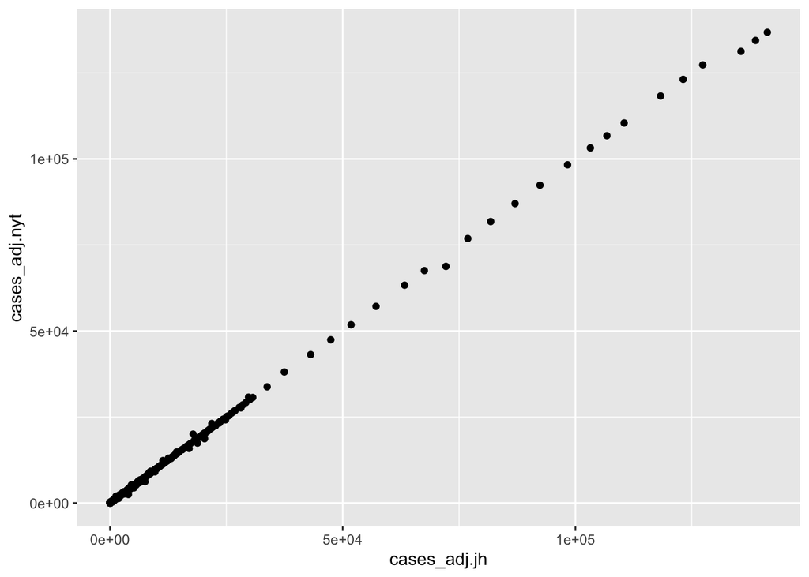

```r
# Plot and correlate cases_adj, deaths_adj  for JH and NYT.

qplot(x=cases_adj.jh, y=cases_adj.nyt, data=df)
```

```r
cases_adj_lm <- lm(cases_adj.jh ~ cases_adj.nyt , data = df)
summary(cases_adj_lm)
```

```
##
## Call:
## lm(formula = cases_adj.jh ~ cases_adj.nyt, data = df)
##
## Residuals:
##     Min      1Q  Median      3Q     Max
## -2308.2     0.4     0.4     0.4  3368.9
##
## Coefficients:
##                 Estimate Std. Error  t value Pr(>|t|)
## (Intercept)   -4.054e-01  3.209e-02   -12.63   <2e-16 ***
## cases_adj.nyt  1.008e+00  3.403e-05 29608.03   <2e-16 ***
## ---
## Signif. codes:  0 '***' 0.001 '**' 0.01 '*' 0.05 '.' 0.1 ' ' 1
##
## Residual standard error: 17.05 on 282868 degrees of freedom
## Multiple R-squared:  0.9997, Adjusted R-squared:  0.9997
## F-statistic: 8.766e+08 on 1 and 282868 DF,  p-value: < 2.2e-16
```

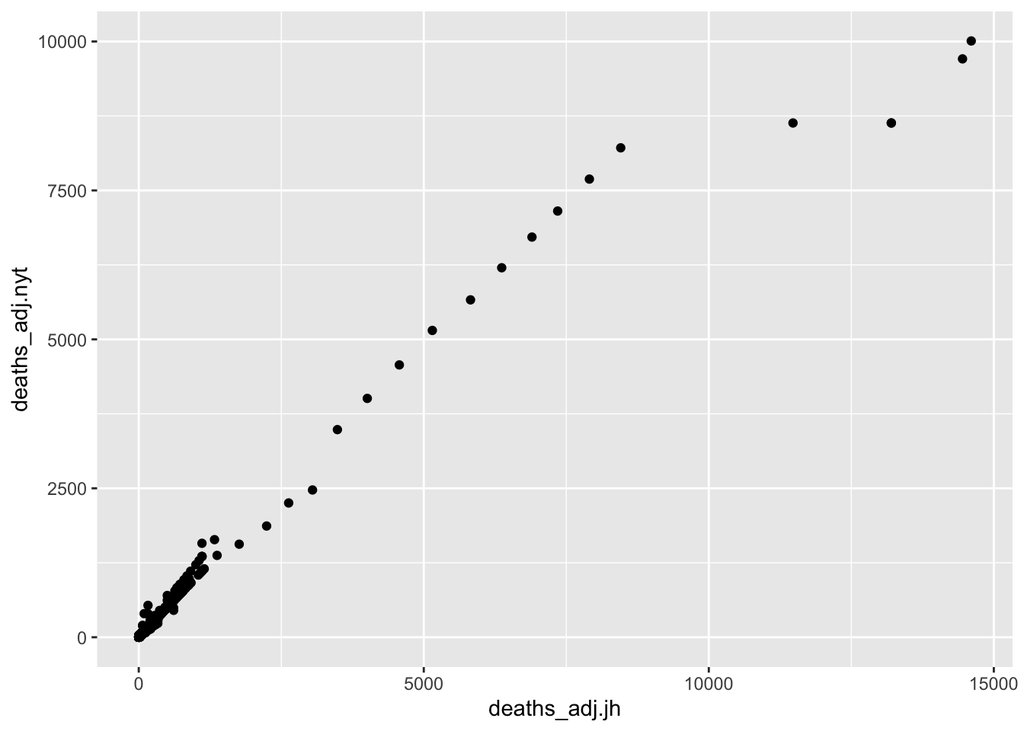

```r
qplot(x=deaths_adj.jh, y=deaths_adj.nyt, data=df)
```

```r
deaths_adj_lm <- lm(deaths_adj.jh ~ deaths_adj.nyt , data = df)
summary(deaths_adj_lm)
```

```
##
## Call:
## lm(formula = deaths_adj.jh ~ deaths_adj.nyt, data = df)
##
## Residuals:
##      Min       1Q   Median       3Q      Max
## -1621.83     0.29     0.29     0.29  2613.65
##
## Coefficients:
##                  Estimate Std. Error t value Pr(>|t|)
## (Intercept)    -0.2860944  0.0250505  -11.42   <2e-16 ***
## deaths_adj.nyt  1.2266726  0.0004467 2746.28   <2e-16 ***
## ---
## Signif. codes:  0 '***' 0.001 '**' 0.01 '*' 0.05 '.' 0.1 ' ' 1
##
## Residual standard error: 13.32 on 282868 degrees of freedom
## Multiple R-squared:  0.9639, Adjusted R-squared:  0.9639
## F-statistic: 7.542e+06 on 1 and 282868 DF,  p-value: < 2.2e-16
```

Adjusted deaths counts do not fit quite as well at the high end in NYC where JH data is noticeably higher than NYT.

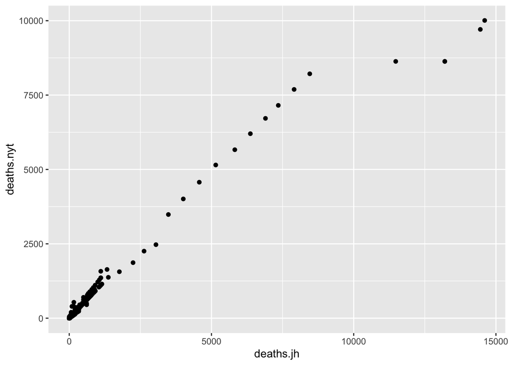

```r
# Same process for unadjusted counts.
qplot(x=deaths.jh, y=deaths.nyt, data = df)
```

```r
deaths_lm <- lm(deaths.jh ~ deaths.nyt , data = df)
summary(deaths_lm)
```

```
##
## Call:
## lm(formula = deaths.jh ~ deaths.nyt, data = df)
##
## Residuals:
##      Min       1Q   Median       3Q      Max
## -1624.04     0.86     1.09     1.09  2611.29
##
## Coefficients:
##               Estimate Std. Error t value Pr(>|t|)
## (Intercept) -1.0857513  0.0946829  -11.47   <2e-16 ***
## deaths.nyt   1.2270389  0.0008687 1412.55   <2e-16 ***
## ---
## Signif. codes:  0 '***' 0.001 '**' 0.01 '*' 0.05 '.' 0.1 ' ' 1
##
## Residual standard error: 25.88 on 74884 degrees of freedom
##   (207984 observations deleted due to missingness)
## Multiple R-squared:  0.9638, Adjusted R-squared:  0.9638
## F-statistic: 1.995e+06 on 1 and 74884 DF,  p-value: < 2.2e-16
```

This is generally a function of the underlying unadjusted data, not something having to with the adjustment process.

# Differences by county

```r
# Check which counties have the most instances of a discrepancy between JH and NYT deaths data.
df_diff_county %>%
  arrange(desc(count_deaths_adj)) %>%
  select(FIPS, state, full_name, count_deaths_adj, sum_deaths_adj, max_deaths_adj)
```

```
## # A tibble: 3,143 x 6
## # Groups:   FIPS, full_name, state [3,143]
##    FIPS  state    full_name       count_deaths_adj sum_deaths_adj max_deaths_adj
##    <chr> <chr>    <chr>                      <int>          <dbl>          <dbl>
##  1 53033 Washing… King, Washingt…               49           8.52          0
##  2 53025 Washing… Grant, Washing…               43          55.3           2.05
##  3 46035 South D… Davison, South…               42         212.            0
##  4 46103 South D… Pennington, So…               41          36.0           0.879
##  5 53061 Washing… Snohomish, Was…               38           5.84          0.243
##  6 06085 Califor… Santa Clara, C…               35           2.39          0
##  7 51095 Virginia James City, Vi…               35          45.7           0
##  8 53007 Washing… Chelan, Washin…               32          41.5           0
##  9 25013 Massach… Hampden, Massa…               30          43.3           0
## 10 25025 Massach… Suffolk, Massa…               30          34.7           6.97
## # … with 3,133 more rows
```

```r
# Check which counties have the largest aggregated discrepancy between JH and NYT deaths data.
df_diff_county %>%
  arrange(desc(sum_deaths_adj)) %>%
  select(FIPS, state, full_name, count_deaths_adj, sum_deaths_adj, max_deaths_adj)
```

```
## # A tibble: 3,143 x 6
## # Groups:   FIPS, full_name, state [3,143]
##    FIPS  state    full_name       count_deaths_adj sum_deaths_adj max_deaths_adj
##    <chr> <chr>    <chr>                      <int>          <dbl>          <dbl>
##  1 36061 New York New York City,…               27           421.          81.7
##  2 36059 New York Nassau, New Yo…               29           308.           0
##  3 36087 New York Rockland, New …               27           283.          30.7
##  4 36079 New York Putnam, New Yo…               18           266.           7.12
##  5 46035 South D… Davison, South…               42           212.           0
##  6 31041 Nebraska Custer, Nebras…               15           204.           0
##  7 13273 Georgia  Terrell, Georg…                7           176.           0
##  8 21143 Kentucky Lyon, Kentucky…                7           171.           0
##  9 36071 New York Orange, New Yo…               26           167.          17.4
## 10 13007 Georgia  Baker, Georgia…                5           165.           0
## # … with 3,133 more rows
```

The largest aggregated absolute differences are, for the most part, in NY where the counts are the highest.

I want to see what this data looks like for a handful of counties of interest.

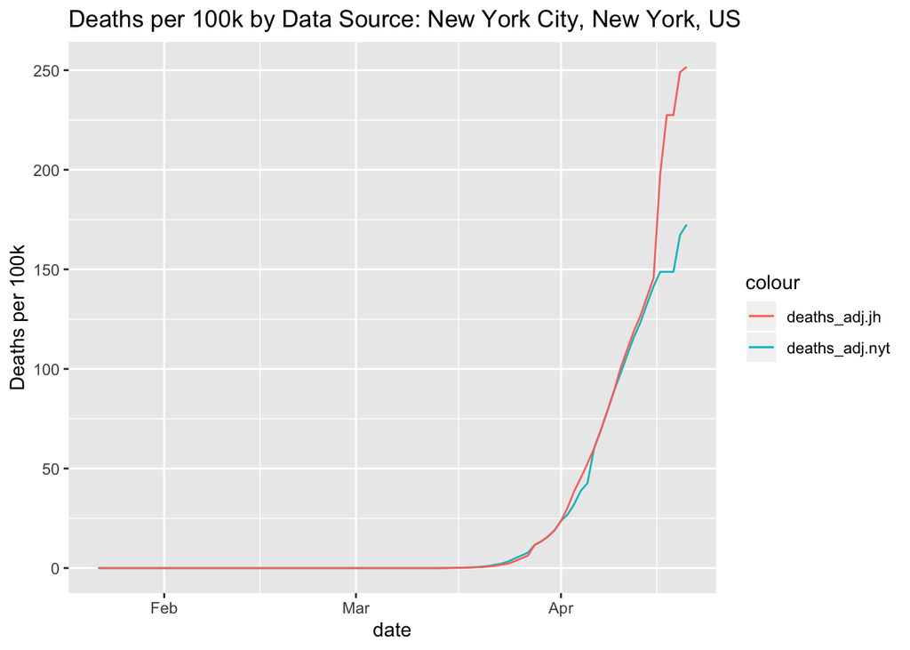

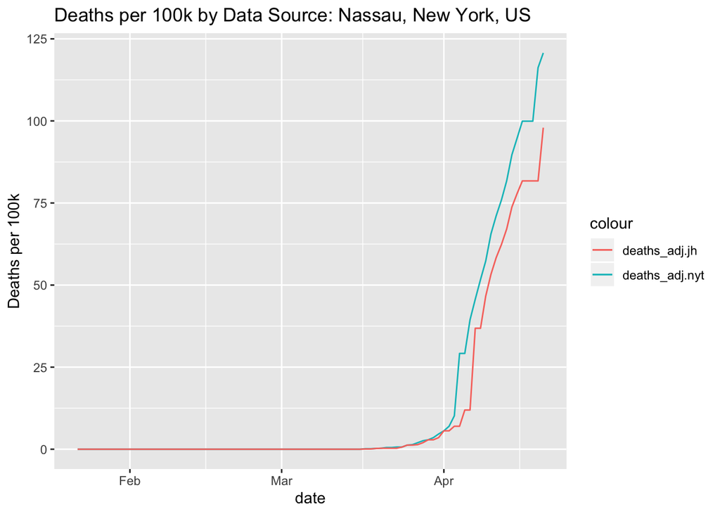

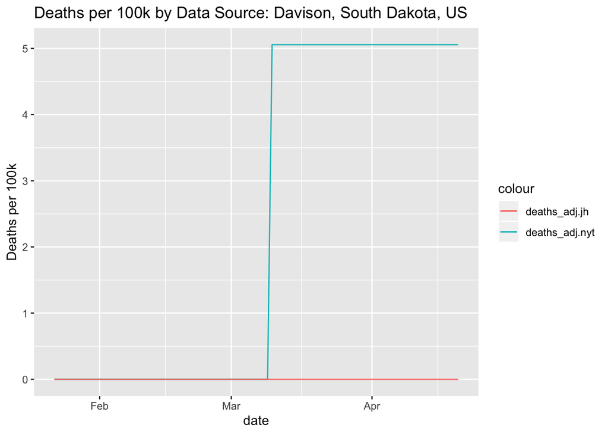

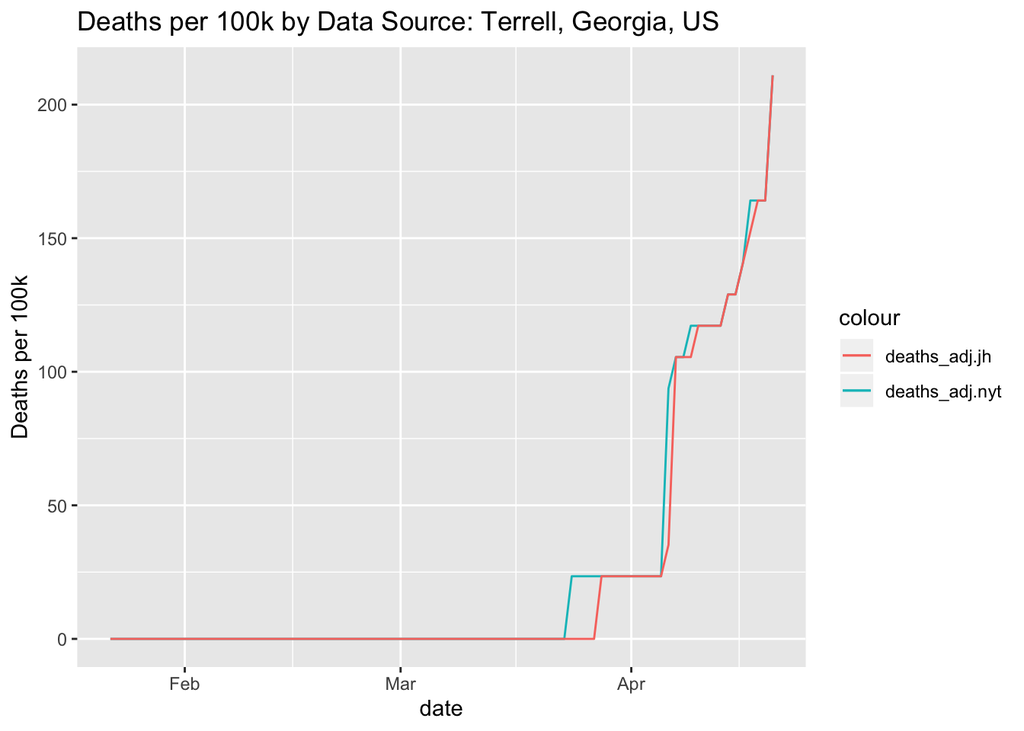

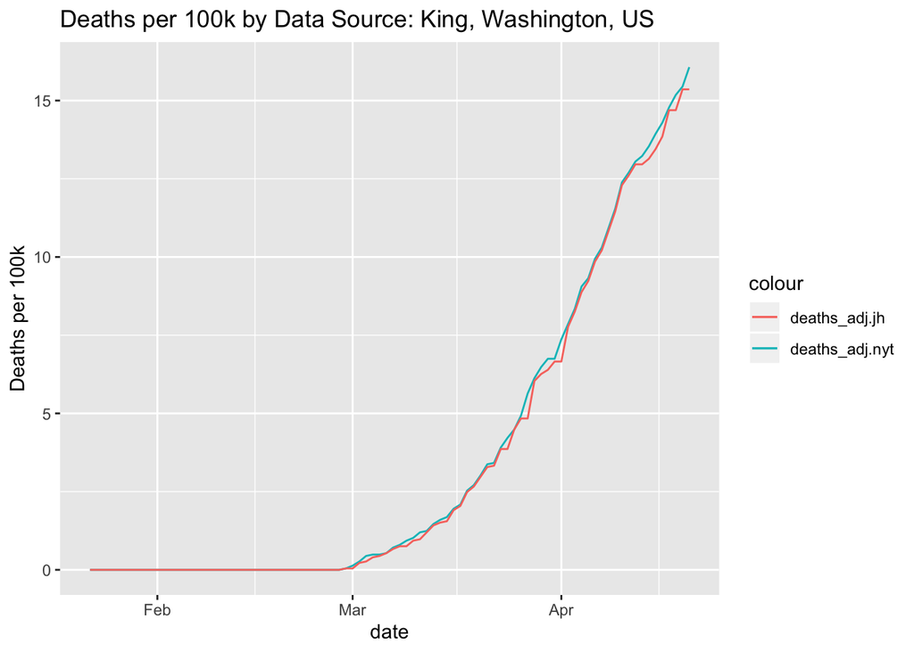

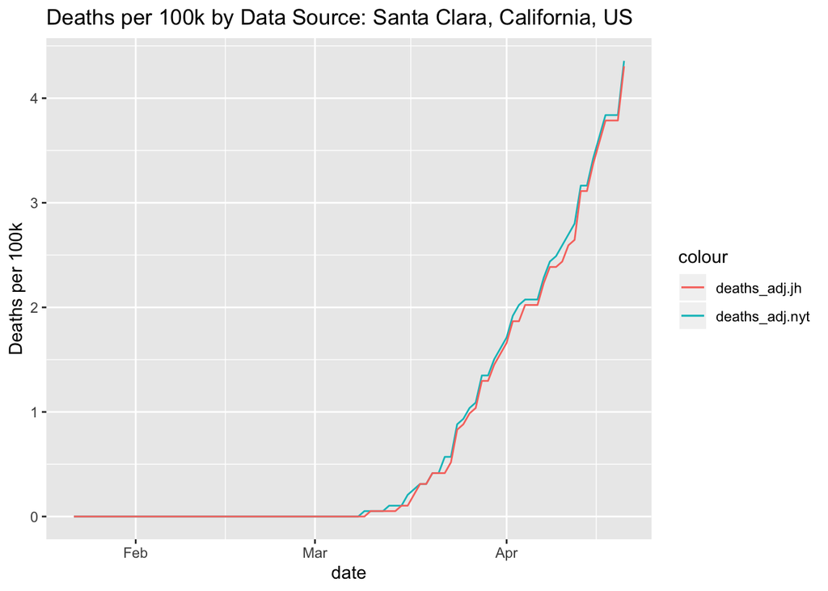

```r
# Plot death total for NYT and JH over time in: NYC; Nassau, NY; King, WA; Davison, SD; Terrell, GA; Santa Clara, CA

county_list <- c("New York City, New York, US", "Nassau, New York, US", "Davison, South Dakota, US", "Terrell, Georgia, US", "King, Washington, US", "Santa Clara, California, US")
county_deaths_plot = list()
for(i in 1:length(county_list)) {
p <- df %>%
  filter(full_name == county_list[i]) %>%
  ggplot() +

  geom_line(aes(x=date, y=100000*(deaths_adj.nyt/population.jh), group=full_name, color="deaths_adj.nyt")) +
  geom_line(aes(x=date, y=100000*(deaths_adj.jh/population.jh), group=full_name, color="deaths_adj.jh")) +

  labs(title=paste("Deaths per 100k by Data Source:", county_list[i]), y="Deaths per 100k")
county_deaths_plot[[i]] = p
}
county_deaths_plot
```

Anecdotally, these still track each other reasonably well except for the large discrepancy in NYC. Maybe JH is allocating more deaths to the city and NYT is allocating more to surrounding counties?

Run the same process for case counts.

```r
# Check which counties have the most instances of a discrepancy between JH and NYT cases data.
df_diff_county %>%
  arrange(desc(count_cases_adj)) %>%
  select(FIPS, state, full_name, count_cases_adj, sum_cases_adj, max_cases_adj)
```

```
## # A tibble: 3,143 x 6
## # Groups:   FIPS, full_name, state [3,143]
##    FIPS  state    full_name          count_cases_adj sum_cases_adj max_cases_adj
##    <chr> <chr>    <chr>                        <int>         <dbl>         <dbl>
##  1 53033 Washing… King, Washington,…              87          79.4        3.02
##  2 53061 Washing… Snohomish, Washin…              83          56.9        5.35
##  3 06075 Califor… San Francisco, Ca…              71          22.6        0
##  4 06073 Califor… San Diego, Califo…              67          70.4        0.0599
##  5 31055 Nebraska Douglas, Nebraska…              64         181.         0
##  6 48029 Texas    Bexar, Texas, US                63          58.6        0.599
##  7 06069 Califor… San Benito, Calif…              60         207.         4.78
##  8 06095 Califor… Solano, Californi…              57         116.         0
##  9 06055 Califor… Napa, California,…              52          51.5        0
## 10 06001 Califor… Alameda, Californ…              50          66.8        0
## # … with 3,133 more rows
```

```r
# Check which counties have the largest aggregated discrepancy between JH and NYT cases data.
df_diff_county %>%
  arrange(desc(sum_cases_adj)) %>%
  select(FIPS, state, full_name, count_cases_adj, sum_cases_adj, max_cases_adj)
```

```
## # A tibble: 3,143 x 6
## # Groups:   FIPS, full_name, state [3,143]
##    FIPS  state    full_name          count_cases_adj sum_cases_adj max_cases_adj
##    <chr> <chr>    <chr>                        <int>         <dbl>         <dbl>
##  1 25019 Massach… Nantucket, Massac…              31         1798.          0
##  2 16013 Idaho    Blaine, Idaho, US               30         1551.         60.8
##  3 25007 Massach… Dukes and Nantuck…              31         1264.         57.7
##  4 36079 New York Putnam, New York,…              22         1089.        189.
##  5 49029 Utah     Morgan, Utah, US                26         1031.          0
##  6 31107 Nebraska Knox, Nebraska, US              41          888.         24.0
##  7 21031 Kentucky Butler, Kentucky,…              12          862.          0
##  8 31079 Nebraska Hall, Nebraska, US              17          802.          0
##  9 13099 Georgia  Early, Georgia, US              20          756.          9.81
## 10 36071 New York Orange, New York,…              16          753.        112.
## # … with 3,133 more rows
```

Another note on Dukes and Nantucket here: - NYT has a Dukes County and a separate Nantucket County, with data for both - The raw JH data has Dukes (all 0’s for cases, deaths and was thrown out), Nantucket (all 0’s, but we kept it in), Dukes and Nantucket (the one we kept and added FIPS for, which has fairly accurate combined counts)

It looks like the census data has these as two separate counties with separate FIPS, which is another point in favor of NYT.

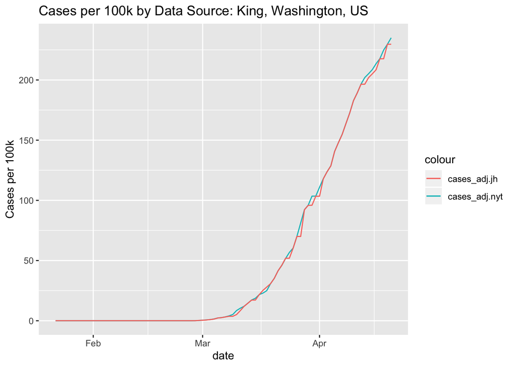

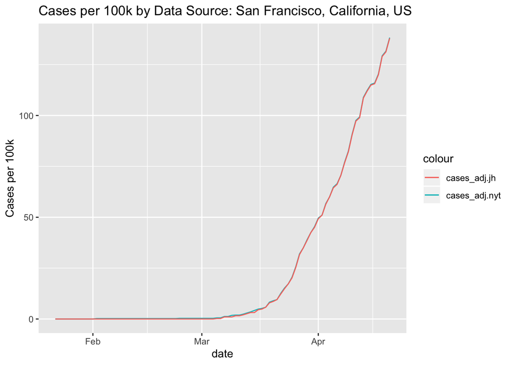

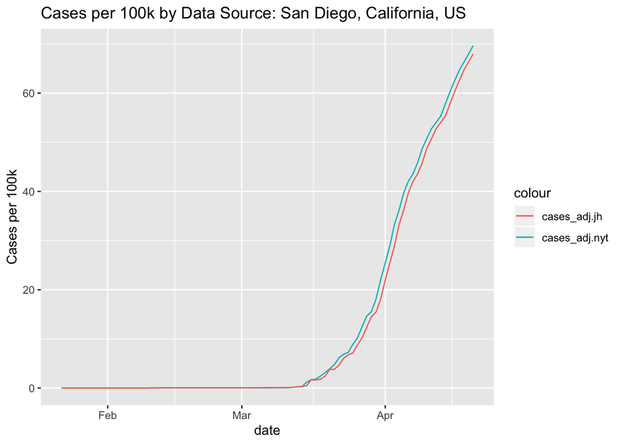

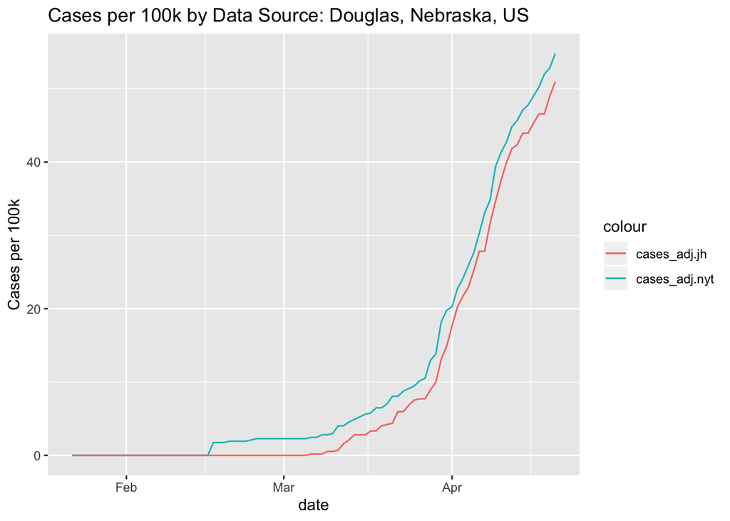

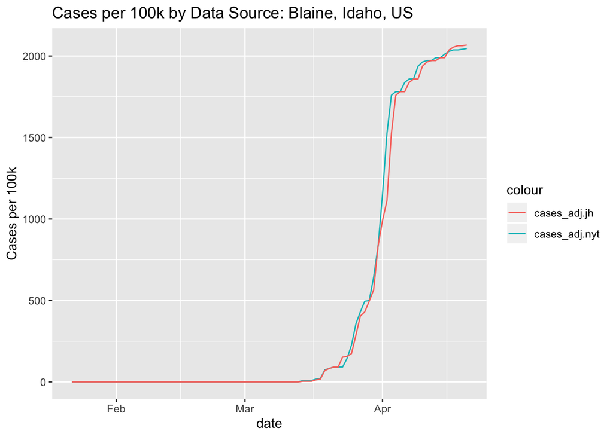

```r
# Plot case total for NYT and JH over time in: King, WA; SF; SD; Douglas, NE; Blaine, ID; Orange, NY

county_list <- c( "King, Washington, US", "San Francisco, California, US",  "San Diego, California, US", "Douglas, Nebraska, US" , "Blaine, Idaho, US")
county_cases_plot = list()
for(i in 1:length(county_list)) {
p <- df %>%
  filter(full_name == county_list[i]) %>%
  ggplot() +

  geom_line(aes(x=date, y=100000*(cases_adj.nyt/population.jh), group=full_name, color="cases_adj.nyt")) +
  geom_line(aes(x=date, y=100000*(cases_adj.jh/population.jh), group=full_name, color="cases_adj.jh")) +

  labs(title=paste("Cases per 100k by Data Source:", county_list[i]), y="Cases per 100k")
county_cases_plot[[i]] = p
}
county_cases_plot
```

SF data starts later for JH, but ends up being almost identical. All of these plots generally track each other reasonaby well.

## Suggestion

[output not shown]